# Final Project - Seattle’s Perfect Weekend: Fact or Fiction?

Stephanie Roark

12/9/2018

# Seattle’s Perfect Summer: Fact or Fiction?

The weather in the Pacific Northwest is notoriusly rainy and gloomy, but the summers are gloriously full of perfect weather, or at least that’s what we believe. How many days are actually perfect?

To answer this question, we must first think about what a perfect day means. The temperature should be warm, but not hot and the sun should be shining most if not all of the day. So we can define a perfect day as being between a certain range of temperatures, say between 60 degrees F and 80 degrees F, and little to no precipitation. When defining a perfect day, the precipitation can’t be assumed to be zero because we will often have a small sprinkle over night, but then beautiful blue-skyed days.

We will start our data collection at NOAA and the EPA.

The NOAA website has available a weather dataset measured at Seattle-Tacoma Airport (SeaTac) spanning all the way back to 1948 containing 50 variables including both max and min temperature and precipitation data and is available for download here: Seattle Daily

The EPA has a pre-generated air quality dataset which contains the air quality index by day for every county in the US and spanning from 01.01.1980 to 11.27.2018: AQI

## Data

Let’s start by loading the datasets and taking a look at their structure.

Load the Seattle weather data:

```r
SeattleWeather <- readr::read_csv("SeattleWeather_1948_2017.csv")
kable(head(SeattleWeather))
```

| DATE | PRCP | TMAX | TMIN | RAIN |
| --- | --- | --- | --- | --- |
| 1948-01-01 | 0.47 | 51 | 42 | TRUE |
| 1948-01-02 | 0.59 | 45 | 36 | TRUE |
| 1948-01-03 | 0.42 | 45 | 35 | TRUE |
| 1948-01-04 | 0.31 | 45 | 34 | TRUE |
| 1948-01-05 | 0.17 | 45 | 32 | TRUE |
| 1948-01-06 | 0.44 | 48 | 39 | TRUE |

```r
kable(tail(SeattleWeather))
```

| DATE | PRCP | TMAX | TMIN | RAIN |
| --- | --- | --- | --- | --- |
| 2017-12-09 | 0 | 44 | 29 | FALSE |
| 2017-12-10 | 0 | 49 | 34 | FALSE |
| 2017-12-11 | 0 | 49 | 29 | FALSE |
| 2017-12-12 | 0 | 46 | 32 | FALSE |
| 2017-12-13 | 0 | 48 | 34 | FALSE |
| 2017-12-14 | 0 | 50 | 36 | FALSE |

```r
str(SeattleWeather)
```

```
## Classes 'tbl_df', 'tbl' and 'data.frame':    25551 obs. of  5 variables:
##  $ DATE: Date, format: "1948-01-01" "1948-01-02" ...
##  $ PRCP: num  0.47 0.59 0.42 0.31 0.17 0.44 0.41 0.04 0.12 0.74 ...
##  $ TMAX: int  51 45 45 45 45 48 50 48 50 43 ...
##  $ TMIN: int  42 36 35 34 32 39 40 35 31 34 ...
##  $ RAIN: logi  TRUE TRUE TRUE TRUE TRUE TRUE ...
##  - attr(*, "spec")=List of 2
##   ..$ cols   :List of 5
##   .. ..$ DATE:List of 1
##   .. .. ..$ format: chr ""
##   .. .. ..- attr(*, "class")= chr  "collector_date" "collector"
##   .. ..$ PRCP: list()
##   .. .. ..- attr(*, "class")= chr  "collector_double" "collector"
##   .. ..$ TMAX: list()
##   .. .. ..- attr(*, "class")= chr  "collector_integer" "collector"
##   .. ..$ TMIN: list()
##   .. .. ..- attr(*, "class")= chr  "collector_integer" "collector"
##   .. ..$ RAIN: list()
##   .. .. ..- attr(*, "class")= chr  "collector_logical" "collector"
##   ..$ default: list()
##   .. ..- attr(*, "class")= chr  "collector_guess" "collector"
##   ..- attr(*, "class")= chr "col_spec"
```

Seattle weather is a dataframe with 25551 observations of 5 variables which are DATE, PRCP, TMAX, TMIN, RAIN. Each observation represents a single day’s meausurements.

TMAX and TMIN are integers representing the maximum and minimum temperatures recorded for that day. RAIN is a logical vector which is true if there is 0.01 inches of rain and false if there is 0.0 inches precipitation whereas PRCP is a numeric representing the amount of daily precipitation measured in inches. DATE is already a date factor so it won’t need to be transformed.

Next we must consider air quality as the recent wildfires on the west coast have greatly impacted everyone’s ability to safely go outside and a good air quality rating should be factored into our definition of a perfect day.

We load each year of AQI data from 1980 to present, filtering for only Seattle, King County, Washington, and then create a single data frame for all the years of data.

```r
#data_list <- list()
#for(year in 1980:2018) {
#    temp <- tempfile()
#    base_file_name <- paste0("daily_aqi_by_county_",year)
#    url_name <- paste0("https://aqs.epa.gov/aqsweb/airdata/",base_file_name,".zip")
#    csv_name <- paste0(base_file_name,".csv")
#    download.file(url_name,temp)
#    data <- read_csv(unz(temp, csv_name)) %>%
#        filter(`State Name` == "Washington" & `county Name` == "King")
#    data_list[[year]] <- data
#    unlink(temp)
#}
#AQIdata <- do.call("rbind", data_list)

AQIdata <- readr::read_csv("AQI_KING.csv")
kable(head(AQIdata))
```

| State Name | county Name | State Code | County Code | Date | AQI | Category | Defining Parameter | Defining Site | Number of Sites Reporting |
| --- | --- | --- | --- | --- | --- | --- | --- | --- | --- |
| Washington | King | 53 | 033 | 1980-01-01 | 32 | Good | CO | 53-033-0076 | 11 |
| Washington | King | 53 | 033 | 1980-01-02 | 72 | Moderate | CO | 53-033-0077 | 14 |
| Washington | King | 53 | 033 | 1980-01-03 | 82 | Moderate | CO | 53-033-0062 | 14 |
| Washington | King | 53 | 033 | 1980-01-04 | 128 | Unhealthy for Sensitive Groups | CO | 53-033-0077 | 14 |
| Washington | King | 53 | 033 | 1980-01-05 | 89 | Moderate | CO | 53-033-0077 | 14 |
| Washington | King | 53 | 033 | 1980-01-06 | 61 | Moderate | CO | 53-033-1003 | 14 |

```r
kable(tail(AQIdata))
```

| State Name | county Name | State Code | County Code | Date | AQI | Category | Defining Parameter | Defining Site | Number of Sites Reporting |
| --- | --- | --- | --- | --- | --- | --- | --- | --- | --- |
| Washington | King | 53 | 033 | 2018-07-27 | 64 | Moderate | Ozone | 53-033-0023 | 10 |
| Washington | King | 53 | 033 | 2018-07-28 | 67 | Moderate | Ozone | 53-033-0023 | 10 |
| Washington | King | 53 | 033 | 2018-07-29 | 147 | Unhealthy for Sensitive Groups | Ozone | 53-033-0023 | 10 |
| Washington | King | 53 | 033 | 2018-07-30 | 136 | Unhealthy for Sensitive Groups | Ozone | 53-033-0017 | 10 |
| Washington | King | 53 | 033 | 2018-07-31 | 44 | Good | Ozone | 53-033-0017 | 10 |
| Washington | King | 53 | 033 | 2018-08-01 | 5 | Good | CO | 53-033-0030 | 2 |

```r
str(AQIdata)
```

```
## Classes 'tbl_df', 'tbl' and 'data.frame':    14090 obs. of  10 variables:
##  $ State Name               : chr  "Washington" "Washington" "Washington" "Washington" ...
##  $ county Name              : chr  "King" "King" "King" "King" ...
##  $ State Code               : int  53 53 53 53 53 53 53 53 53 53 ...
##  $ County Code              : chr  "033" "033" "033" "033" ...
##  $ Date                     : Date, format: "1980-01-01" "1980-01-02" ...
##  $ AQI                      : int  32 72 82 128 89 61 103 51 94 63 ...
##  $ Category                 : chr  "Good" "Moderate" "Moderate" "Unhealthy for Sensitive Groups" ...
##  $ Defining Parameter       : chr  "CO" "CO" "CO" "CO" ...
##  $ Defining Site            : chr  "53-033-0076" "53-033-0077" "53-033-0062" "53-033-0077" ...
##  $ Number of Sites Reporting: int  11 14 14 14 14 14 13 14 14 10 ...
##  - attr(*, "spec")=List of 2
##   ..$ cols   :List of 10
##   .. ..$ State Name               : list()
##   .. .. ..- attr(*, "class")= chr  "collector_character" "collector"
##   .. ..$ county Name              : list()
##   .. .. ..- attr(*, "class")= chr  "collector_character" "collector"
##   .. ..$ State Code               : list()
##   .. .. ..- attr(*, "class")= chr  "collector_integer" "collector"
##   .. ..$ County Code              : list()
##   .. .. ..- attr(*, "class")= chr  "collector_character" "collector"
##   .. ..$ Date                     :List of 1
##   .. .. ..$ format: chr ""
##   .. .. ..- attr(*, "class")= chr  "collector_date" "collector"
##   .. ..$ AQI                      : list()
##   .. .. ..- attr(*, "class")= chr  "collector_integer" "collector"
##   .. ..$ Category                 : list()
##   .. .. ..- attr(*, "class")= chr  "collector_character" "collector"
##   .. ..$ Defining Parameter       : list()
##   .. .. ..- attr(*, "class")= chr  "collector_character" "collector"
##   .. ..$ Defining Site            : list()
##   .. .. ..- attr(*, "class")= chr  "collector_character" "collector"
##   .. ..$ Number of Sites Reporting: list()
##   .. .. ..- attr(*, "class")= chr  "collector_integer" "collector"
##   ..$ default: list()
##   .. ..- attr(*, "class")= chr  "collector_guess" "collector"
##   ..- attr(*, "class")= chr "col_spec"
```

The AQI or air quality index data set consists of 14090 observations of 10 variables including State Name, county Name, State Code, County Code, Date, AQI, Category, Defining Parameter, Defining Site, Number of Sites Reporting. Each observation represents a single day’s meausurements. The Date and Category variables are of interest in determining which days had acceptable air quality in Seattle. Once again the Date was read in as a date factor and category is a character.

So now we have 2 dataframes with temperature, precipitation and air quality included. The next step is to combine these dataframes into one table.

Since our AQI dataset only contains data from 1980, we will only have concurrent dates beginning from 01.01.1980 and going to 12.14.2017 which is when the Seattle Weather Data Ends.

```r
### inner join on the dates available
AllWeather <- inner_join(SeattleWeather, AQIdata, by = c("DATE" = "Date"))

#look at how the new table is structured
str(AllWeather)
```

```
## Classes 'tbl_df', 'tbl' and 'data.frame':    13860 obs. of  14 variables:
##  $ DATE                     : Date, format: "1980-01-01" "1980-01-02" ...
##  $ PRCP                     : num  0.22 0.19 0 0.13 0.12 0 0.19 0.37 0.15 0 ...
##  $ TMAX                     : int  52 46 46 40 39 35 30 29 34 38 ...
##  $ TMIN                     : int  44 37 33 34 30 26 24 26 26 28 ...
##  $ RAIN                     : logi  TRUE TRUE FALSE TRUE TRUE FALSE ...
##  $ State Name               : chr  "Washington" "Washington" "Washington" "Washington" ...
##  $ county Name              : chr  "King" "King" "King" "King" ...
##  $ State Code               : int  53 53 53 53 53 53 53 53 53 53 ...
##  $ County Code              : chr  "033" "033" "033" "033" ...
##  $ AQI                      : int  32 72 82 128 89 61 103 51 94 63 ...
##  $ Category                 : chr  "Good" "Moderate" "Moderate" "Unhealthy for Sensitive Groups" ...
##  $ Defining Parameter       : chr  "CO" "CO" "CO" "CO" ...
##  $ Defining Site            : chr  "53-033-0076" "53-033-0077" "53-033-0062" "53-033-0077" ...
##  $ Number of Sites Reporting: int  11 14 14 14 14 14 13 14 14 10 ...
```

```r
#look at the numberic values
#kable(AllWeather %>%
#    select_if(is.numeric) %>%
#    skimr::skim())

kable(AllWeather %>%
    select_if(is.numeric) %>%
    skimr::skim(AQI))
```

| variable | type | stat | level | value | formatted |
| --- | --- | --- | --- | --- | --- |
| AQI | integer | missing | .all | 0.00000 | 0 |
| AQI | integer | complete | .all | 13860.00000 | 13860 |
| AQI | integer | n | .all | 13860.00000 | 13860 |
| AQI | integer | mean | .all | 56.53550 | 56.54 |
| AQI | integer | sd | .all | 26.53875 | 26.54 |
| AQI | integer | p0 | .all | 7.00000 | 7 |
| AQI | integer | p25 | .all | 39.00000 | 39 |
| AQI | integer | p50 | .all | 49.00000 | 49 |
| AQI | integer | p75 | .all | 66.00000 | 66 |
| AQI | integer | p100 | .all | 220.00000 | 220 |
| AQI | integer | hist | .all | NA | ▂▇▂▁▁▁▁▁ |

```r
kable(AllWeather %>%
    select_if(is.numeric) %>%
    skimr::skim(TMAX))
```

| variable | type | stat | level | value | formatted |
| --- | --- | --- | --- | --- | --- |
| TMAX | integer | missing | .all | 0.00000 | 0 |
| TMAX | integer | complete | .all | 13860.00000 | 13860 |
| TMAX | integer | n | .all | 13860.00000 | 13860 |
| TMAX | integer | mean | .all | 60.12345 | 60.12 |
| TMAX | integer | sd | .all | 12.67805 | 12.68 |
| TMAX | integer | p0 | .all | 18.00000 | 18 |
| TMAX | integer | p25 | .all | 50.00000 | 50 |
| TMAX | integer | p50 | .all | 59.00000 | 59 |
| TMAX | integer | p75 | .all | 69.00000 | 69 |
| TMAX | integer | p100 | .all | 103.00000 | 103 |
| TMAX | integer | hist | .all | NA | ▁▁▅▇▆▃▂▁ |

```r
kable(AllWeather %>%
    select_if(is.numeric) %>%
    skimr::skim(TMIN))
```

| variable | type | stat | level | value | formatted |
| --- | --- | --- | --- | --- | --- |
| TMIN | integer | missing | .all | 0.000000 | 0 |
| TMIN | integer | complete | .all | 13860.000000 | 13860 |
| TMIN | integer | n | .all | 13860.000000 | 13860 |
| TMIN | integer | mean | .all | 45.243362 | 45.24 |
| TMIN | integer | sd | .all | 8.771334 | 8.77 |
| TMIN | integer | p0 | .all | 7.000000 | 7 |
| TMIN | integer | p25 | .all | 39.000000 | 39 |
| TMIN | integer | p50 | .all | 45.000000 | 45 |
| TMIN | integer | p75 | .all | 52.000000 | 52 |
| TMIN | integer | p100 | .all | 71.000000 | 71 |
| TMIN | integer | hist | .all | NA | ▁▁▂▆▇▇▃▁ |

```r
kable(AllWeather %>%
    select_if(is.numeric) %>%
    skimr::skim(PRCP))
```

| variable | type | stat | level | value | formatted |
| --- | --- | --- | --- | --- | --- |
| PRCP | numeric | missing | .all | 3.000000e+00 | 3 |
| PRCP | numeric | complete | .all | 1.385700e+04 | 13857 |
| PRCP | numeric | n | .all | 1.386000e+04 | 13860 |
| PRCP | numeric | mean | .all | 1.051519e-01 | 0.11 |
| PRCP | numeric | sd | .all | 2.436655e-01 | 0.24 |
| PRCP | numeric | p0 | .all | 0.000000e+00 | 0 |
| PRCP | numeric | p25 | .all | 0.000000e+00 | 0 |
| PRCP | numeric | p50 | .all | 0.000000e+00 | 0 |
| PRCP | numeric | p75 | .all | 1.000000e-01 | 0.1 |
| PRCP | numeric | p100 | .all | 5.020000e+00 | 5.02 |
| PRCP | numeric | hist | .all | NA | ▇▁▁▁▁▁▁▁ |

```r
#how many NA's are in the new table
sum(is.na(AllWeather))
```

```
## [1] 6
```

Now that we have our two datasets joined together, let’s take a look at the max and min temp ranges for each year with air quality.

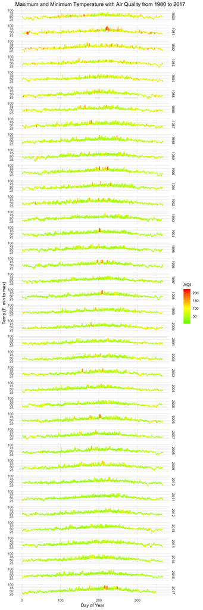

```r
#plot tmin and tmax against date - color green for good days and red for bad
AllWeather %>% #filter(year(DATE) < 1985 ) %>%
    mutate(year = year(DATE), day_of_year = yday(DATE) ) %>%
    ggplot(aes(x=day_of_year, ymin=TMIN, ymax=TMAX, colour=AQI)) +
    geom_linerange(size=0.5) +
    scale_colour_gradient2(low = "green", mid="yellow", high = "red", midpoint = 100) +
    # 125 is the midpoint of the "Unhealthy for Sensitive Groups" level
    # 100 is the transition point from "Moderate" to "Unhealthy for Sensitive Groups"
    facet_grid( year ~ .) +
    xlab("Day of Year") + ylab("Temp (F, min to max)") +
    ggtitle("Maximum and Minimum Temperature with Air Quality from 1980 to 2017") +
    theme_minimal()
```

From the plots we can see that air quality tends to be an issue in the summer time.

And now the precipitation by day for each year.

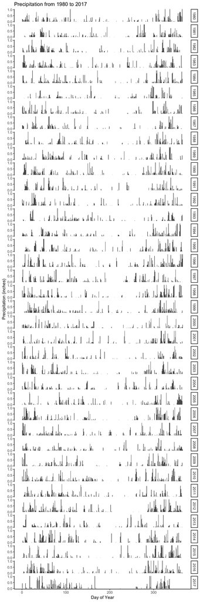

```r
AllWeather %>%
    mutate(year = year(DATE), day_of_year = yday(DATE) ) %>%
    ggplot(aes(x=day_of_year, y=PRCP)) +
    geom_bar(stat="identity") +
    facet_grid( year ~ .) +
    xlab("Day of Year") + ylab("Precipitation (inches)") +
    coord_cartesian(ylim = c(0, 1)) +
    scale_y_continuous(breaks=c(0,0.5,1)) +
    ggtitle("Precipitation from 1980 to 2017") +
    theme_classic()
```

There are definite gaps in the precipitation each year which makes sense as the summers tend to be very dry. It is interesting to see how the dry weather gaps do not occur consistently at the same time of year.